# Tutorial - como gerar os gráficos boxplot no R

Leonardo Fernandes Wink

27/12/2022

# Primeiro acesso

1. Se é o seu primeiro acesso, clique na caixinha `Code` no canto superior direito para baixar o código no formato `.Rmd`, ou seja, RMarkdown.
2. Abra o RStudio
3. Clique em File -> Open file -> e selecione esse arquivo `.Rmd` que você baixou.
4. Você deve chegar a uma tela semelhante a da figura abaixo

[figure not shown]

Na primeira vez em que for rodar os códigos aqui no R, será solicitado que instale pacotes. Quando aparecerem caixas de diálogo, clique em **`Yes`**. Pode demorar um pouco esse processo. Para ter uma melhor visualização desse tutorial pressione as teclas `Ctrl+Shift+K` ou clique no botão `Knit` acima. Recomendo manter uma aba do navegador com o arquivo `tutorial_R.html` aberto.

Já podemos rodar o código pela primeira vez!  
Para isso, aperte `Ctrl+Alt+R` ou clique em `Run` no menu superior e depois em `Run All`:

[figure not shown]

Enquanto os pacotes estão sendo instalados, prossiga com a leitura.

Quando quiser renderizar o código para ter a mesma visualização como a do formato `.html` use o comando de `Knit`, o `Ctrl+Shift+K`, ou caso esteja com um gráfico aberto, clique em Viewer na janela inferior direita.

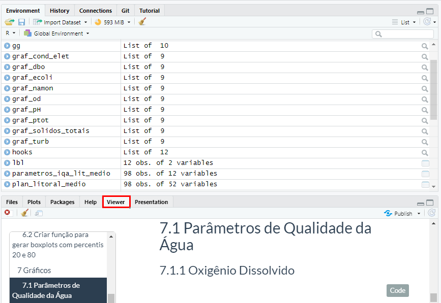

# 1 Comandos mais utilizados

`Ctrl+Alt+R` -> executa TODOS os códigos de uma vez só.

`Knit` ou `Ctrl+Shift+K` -> roda TODOS os códigos de uma vez só e renderiza a visualização em formatos `.html` ou `.pdf`.

`Ctrl+Enter` -> executa um “parágrafo” de códigos.

`Alt+Enter` -> executa o “parágrafo” de códigos mas sem mover o cursor.

`Ctrl+Shift+C` -> para comentar ou *descomentar* um intervalo de linhas.

> As linhas de código que começam com `#` são **comentários**. Elas não impactam o resultado final do código.

`Ctrl+Alt+I` -> cria um novo *code chunk*.

`Ctrl+I` -> Indenta o código (ajusta a tabulação entre as linhas, facilita a leitura do código).

> A lista completa de atalhos pode ser conferida no menu superior Tools -> Keyboard Shortcuts Help, ou através do atalho `Alt+Shift+K`.

# 2 Passo-a-passo

> **Importante**: Com esse arquivo `.Rmd` você deve chegar aos mesmos resultados que presentes no arquivo `tutorial_R.html`.

> Vou deixar comentado os pedaços de código que necessitam de alteração obrigatória com a nomenclatura `alteracao_` seguido de um número.

# 3 Pacotes necessários

```r
pacman::p_load(readr, readxl,
               rmarkdown,
               dplyr, tidyverse, glue,
               knitr, kableExtra,
               ggplot2,
               ggbeeswarm, GGally,
               lubridate,
               ggtext,
               bookdown
               #googlesheets4
               )
```

# 4 Importação dos dados

```r
plan_litoral_medio <- read_delim(
  "https://raw.githubusercontent.com/leonardofwink/tutorial_R_fepam/main/planilha_rsagua/plan_litoral_medio%20-%20Dados_Ajustados.tsv",
  delim = "\t",
  escape_double = FALSE,
  col_types = cols(
    ÍNDICE = col_number(),
    `CÓD. ESTAÇÃO` = col_character(),
    LATITUDE = col_number(),
    LONGITUDE = col_number(),
    `BACIA HIDROGRÁFICA` = col_character(),
    `RECURSO HÍDRICO` = col_character(),
    REGIÃO = col_character(),
    MUNICÍPIO = col_character(),
    AMBIENTE = col_character(),
    `DATA COLETA` = col_date(format = "%m/%d/%Y"),
    `HORA COLETA` = col_time(format = "%H:%M:%S"),
    `CHUVA 24H` = col_character(),
    ALCALINIDADE = col_number(),
    ALUMÍNIO = col_number(),
    CÁDMIO = col_number(),
    CHUMBO = col_number(),
    CLORETO = col_number(),
    `CLOROFILA A` = col_number(),
    COBRE = col_number(),
    `COLIFORMES TERMOTOLERANTES` = col_number(),
    `COLIFORMES TOTAIS` = col_number(),
    CONDUTIVIDADE = col_number(),
    `CROMO TOTAL` = col_number(),
    `DEMANDA BIOQUÍMICA DE OXIGÊNIO` = col_number(),
    `DEMANDA QUÍMICA DE OXIGÊNIO` = col_number(),
    `ESCHERICHIA COLI` = col_number(),
    FERRO = col_number(),
    `FITOPLANCTON  - CIANOBACTÉRIAS` = col_number(),
    `FOSFATO ORTO` = col_number(),
    `FÓSFORO TOTAL` = col_number(),
    MANGANÊS = col_number(),
    `MERCÚRIO EM MICROGRAMA POR LITRO (UG/L)` = col_number(),
    NÍQUEL = col_number(),
    NITRATO = col_number(),
    `NITROGÊNIO AMONIACAL` = col_number(),
    `NITROGÊNIO ORGÂNICO` = col_number(),
    `NITROGÊNIO TOTAL KJELDAHL` = col_number(),
    `OXIGÊNIO DISSOLVIDO` = col_number(),
    PH = col_number(),
    `PROFUNDIDADE COLETA` = col_number(),
    `PROFUNDIDADE TOTAL` = col_number(),
    SALINIDADE = col_number(),
    `SÓLIDOS DISSOLVIDOS TOTAIS` = col_number(),
    `SÓLIDOS SUSPENSOS TOTAIS` = col_number(),
    `SÓLIDOS TOTAIS` = col_number(),
    `TEMPERATURA DA ÁGUA` = col_number(),
    `TEMPERATURA DO AR` = col_number(),
    `TRANSPARÊNCIA DA ÁGUA` = col_number(),
    TURBIDEZ = col_number(),
    `VAZÃO RECURSO HÍDRICO` = col_number(),
    ZINCO = col_number()
  ),
  locale = locale(
    date_names = "pt",
    decimal_mark = ",",
    grouping_mark = ""
  ),
  trim_ws = TRUE
) %>%
  janitor::clean_names() %>%
  slice(
    1:(n() - 8) #retirando as ultimas 8 linhas
  ) %>%
  rename(
    e_coli = escherichia_coli,
    dbo = demanda_bioquimica_de_oxigenio,
    mercurio = mercurio_em_micrograma_por_litro_ug_l
  ) %>%
  mutate(
    municipio = str_to_title(municipio),
    data_coleta = ymd(data_coleta),
    ano_coleta = year(data_coleta),
  ) %>%
  dplyr::select( #reordenando as colunas
    c(1:10),
    ano_coleta,
    everything()
  )
```

```r
plan_litoral_medio_alterar <- read_excel(
  "C:/Users/Léo/Downloads/plan_litoral_medio.xls", #alteracao_1
  sheet = "Dados_Ajustados",
  col_types = c(
    "numeric", "text", "numeric", "numeric", "text",
    "text", "text", "text", "text", "date",
    "date", "text", "numeric", "numeric",
    "numeric", "numeric", "numeric",
    "numeric", "numeric", "numeric",
    "numeric", "numeric", "numeric",
    "numeric", "numeric", "numeric",
    "numeric", "numeric", "numeric",
    "numeric", "numeric", "numeric",
    "numeric", "numeric", "numeric",
    "numeric", "numeric", "numeric",
    "numeric", "numeric", "numeric",
    "numeric", "numeric", "numeric",
    "numeric", "numeric", "numeric",
    "numeric", "numeric", "numeric",
    "numeric"),
  range = "A1:AY99", #alteracao_2
  trim_ws = TRUE
) %>%
  janitor::clean_names() %>%
  rename(
    e_coli = escherichia_coli,
    dbo = demanda_bioquimica_de_oxigenio,
    mercurio = mercurio_em_micrograma_por_litro_ug_l
  ) %>%
  mutate(
    municipio = str_to_title(municipio),
    data_coleta = ymd(data_coleta),
    ano_coleta = year(data_coleta),
    # hora_coleta = parse_datetime(hora_coleta),
  ) %>%
  dplyr::select( #reordenando as colunas
    c(1:10),
    ano_coleta,
    everything()
  )
```

# 5 Sumários estatísticos

```r
sumario <- plan_litoral_medio %>%
  dplyr::select(cod_estacao, oxigenio_dissolvido, ano_coleta) %>%
  filter(ano_coleta > "2013" &
           ano_coleta <= "2025") %>%
  group_by(cod_estacao) %>%
  summarize(
    min =
      min(oxigenio_dissolvido,
          na.rm = TRUE),
    q1 =
      quantile(oxigenio_dissolvido, 0.25,
               na.rm = TRUE),
    median =
      median(oxigenio_dissolvido,
             na.rm = TRUE),
    mean =
      mean(oxigenio_dissolvido,
           na.rm= TRUE),
    q3 =
      quantile(oxigenio_dissolvido, 0.75,
               na.rm = TRUE),
    max =
      max(oxigenio_dissolvido,
          na.rm = TRUE))

sumario
```

**output**

```
## # A tibble: 6 x 7
##   cod_estacao   min    q1 median  mean    q3   max
##   <chr>       <dbl> <dbl>  <dbl> <dbl> <dbl> <dbl>
## 1 87332500     0     3.5    4.94  4.75  6.57  9.23
## 2 87420130     8.14  8.73   9.06  9.15  9.52 10.6
## 3 87420150     6.7   8.21   8.41  8.49  8.63  9.83
## 4 87420350     5.93  7.04   8.34  8.07  8.99  9.64
## 5 87420500     4.65  6.87   7.25  7.50  8.61 11.0
## 6 87510010     2.32  4.23   5.9   5.53  6.71  8.24
```

## 5.1 Visualização da estrutura de dados da planilha

Conferir se o tipo dos dados está correto, data em formato de data (date/dttm), código da estação como character (chr), valor medido dos parâmetros como double (dbl).

```r
glimpse(plan_litoral_medio)
```

**output**

```
## Rows: 98
## Columns: 52
## $ indice                      <dbl> 1, 2, 3, 4, 5, 6, 7, 8, 9, 10, 11, 12, 13,~
## $ cod_estacao                 <chr> "87332500", "87332500", "87332500", "87332~
## $ latitude                    <dbl> -29.91447, -29.91447, -29.91447, -29.91447~
## $ longitude                   <dbl> -50.31819, -50.31819, -50.31819, -50.31819~
## $ bacia_hidrografica          <chr> "Litoral Médio", "Litoral Médio", "Litoral~
## $ recurso_hidrico             <chr> "Lagoa dos Barros", "Lagoa dos Barros", "L~
## $ regiao                      <chr> "Litoral", "Litoral", "Litoral", "Litoral"~
## $ municipio                   <chr> "Osorio", "Osorio", "Osorio", "Osorio", "O~
## $ ambiente                    <chr> "Lêntico", "Lêntico", "Lêntico", "Lêntico"~
## $ data_coleta                 <date> 2016-06-29, 2016-09-26, 2016-12-14, 2017-~
## $ ano_coleta                  <dbl> 2016, 2016, 2016, 2017, 2017, 2017, 2017, ~
## $ hora_coleta                 <time> 10:50:00, 11:05:00, 10:21:00, 11:00:00, 1~
## $ chuva_24h                   <chr> "AUSENTE", "AUSENTE", "AUSENTE", "AUSENTE"~
```

[output cut: 39 more lines]

```r
# str(plan_litoral_medio) #outra maneira de visualizar a eSTRutura
```

| indice | cod_estacao | latitude | longitude | bacia_hidrografica | recurso_hidrico | regiao | municipio | ambiente | data_coleta | ano_coleta | hora_coleta | chuva_24h | alcalinidade | aluminio | cadmio | chumbo | cloreto | clorofila_a | cobre | coliformes_termotolerantes | coliformes_totais | condutividade | cromo_total | dbo | demanda_quimica_de_oxigenio | e_coli | ferro | fitoplancton_cianobacterias | fosfato_orto | … |
| --- | --- | --- | --- | --- | --- | --- | --- | --- | --- | --- | --- | --- | --- | --- | --- | --- | --- | --- | --- | --- | --- | --- | --- | --- | --- | --- | --- | --- | --- | --- |
| 1 | 87332500 | -29.91447 | -50.31819 | Litoral Médio | Lagoa dos Barros | Litoral | Osorio | Lêntico | 2016-06-29 | 2016 | 10:50:00 | AUSENTE | 35.0 | NA | NA | NA | 27.80 | NA | NA | NA | NA | 123.30 | NA | 3 | 31 | 173.1 | NA | 171 | 0.071 | … |
| 2 | 87332500 | -29.91447 | -50.31819 | Litoral Médio | Lagoa dos Barros | Litoral | Osorio | Lêntico | 2016-09-26 | 2016 | 11:05:00 | AUSENTE | 11.0 | NA | NA | NA | 10.10 | 2.19 | NA | NA | NA | 81.00 | NA | 1 | 15 | 28.8 | NA | 47 | 0.101 | … |
| 3 | 87332500 | -29.91447 | -50.31819 | Litoral Médio | Lagoa dos Barros | Litoral | Osorio | Lêntico | 2016-12-14 | 2016 | 10:21:00 | AUSENTE | 7.7 | NA | NA | NA | 9.60 | 7.64 | NA | NA | NA | 66.60 | NA | 2 | 27 | 122.3 | NA | 1368 | 0.089 | … |
| 4 | 87332500 | -29.91447 | -50.31819 | Litoral Médio | Lagoa dos Barros | Litoral | Osorio | Lêntico | 2017-03-27 | 2017 | 11:00:00 | AUSENTE | 42.5 | NA | NA | NA | 14.30 | 40.10 | NA | NA | NA | 139.10 | NA | 4 | 24 | 770.1 | NA | 129 | 0.184 | … |
| 5 | 87332500 | -29.91447 | -50.31819 | Litoral Médio | Lagoa dos Barros | Litoral | Osorio | Lêntico | 2017-06-26 | 2017 | 10:50:00 | AUSENTE | 22.1 | NA | 0.003 | NA | 10.10 | 5.53 | 0.0040 | NA | NA | 65.40 | NA | 2 | 14 | 49.6 | 3.1200 | 438 | 0.109 | … |
| 6 | 87332500 | -29.91447 | -50.31819 | Litoral Médio | Lagoa dos Barros | Litoral | Osorio | Lêntico | 2017-09-25 | 2017 | 10:55:00 | AUSENTE | 14.9 | NA | 0.003 | NA | 8.60 | 3.56 | 0.0020 | NA | NA | 69.00 | NA | 2 | 17 | 34.7 | 3.5500 | 68 | 0.118 | … |
| 7 | 87332500 | -29.91447 | -50.31819 | Litoral Médio | Lagoa dos Barros | Litoral | Osorio | Lêntico | 2017-12-26 | 2017 | 11:30:00 | AUSENTE | 19.4 | NA | 0.001 | NA | 8.80 | 2.67 | 0.0030 | NA | NA | 75.60 | NA | 2 | 32 | 344.2 | 1.9400 | 242 | 0.092 | … |
| 8 | 87332500 | -29.91447 | -50.31819 | Litoral Médio | Lagoa dos Barros | Litoral | Osorio | Lêntico | 2018-03-28 | 2018 | 10:15:00 | AUSENTE | 39.8 | 0.0015 | 0.001 | 0.002 | 15.90 | 1.84 | 0.0070 | NA | NA | 149.30 | 0.002 | 4 | 40 | NA | 2.9600 | 2901 | 0.195 | … |
| 9 | 87332500 | -29.91447 | -50.31819 | Litoral Médio | Lagoa dos Barros | Litoral | Osorio | Lêntico | 2018-06-25 | 2018 | 11:20:00 | AUSENTE | 27.2 | 0.0120 | 0.001 | 0.016 | 9.80 | 0.50 | 0.0050 | NA | NA | 87.70 | 0.009 | 4 | 38 | NA | 5.4000 | 1812 | 0.196 | … |
| 10 | 87332500 | -29.91447 | -50.31819 | Litoral Médio | Lagoa dos Barros | Litoral | Osorio | Lêntico | 2018-09-24 | 2018 | 10:14:00 | AUSENTE | 23.9 | NA | 0.003 | NA | 9.80 | 6.02 | 0.0020 | NA | NA | 83.70 | NA | 1 | 23 | 770.1 | 3.3500 | 267 | 0.041 | … |

[output cut: 88 more lines]

# 6 Requisitos pra gerar os gráficos

## 6.1 Definir o *theme*

Definindo uma cor de letra e de fundo padrão a ser adotada nos gráficos.

```r
theme_grafs <- function(bg = "white",
                        coloracao_letra = "black") {
  theme(
    plot.title =
      element_text(
        hjust = 0.5,
        color = coloracao_letra,
        size = 19),

    axis.title.x =
      # element_text(
      # color = coloracao_letra,
      # size = 15,
      # angle = 0,),
      element_blank(),
    axis.title.y = element_text(
      color = coloracao_letra,
      size = 15,
      angle = 90),

    axis.text.x = element_text(
      color = coloracao_letra,
      size = 17),
    axis.text.y = element_text(
      color = coloracao_letra,
      size = 17,
      angle = 0),

    strip.background = element_rect(fill = bg,
                                    linetype = 1,
                                    size = 0.5,
                                    color = "black"),
    strip.text = element_text(size = 17),
    panel.background = element_rect(fill = bg),
    plot.background = element_rect(fill = bg),
    plot.margin = margin(l = 5, r = 10,
                         b = 5, t = 5)
  )
}
```

## 6.2 Criar função para gerar boxplots com percentis 20 e 80

```r
f <- function(x) {
  r <- quantile(x, probs = c(0.10, 0.20, 0.50, 0.80, 0.90))
  names(r) <- c("ymin", "lower", "middle", "upper", "ymax")
  return(r)
}
```

# 7 Gráficos

> **Atenção:** Tomar muito cuidado com a ordem que estão dispostas as estações. Deve-se sempre respeitar o sentido nascente -> foz.

> Conferir a ordem das estações através do mapa interativo.

> Para reordenar as estações, fazer como descrito no code chunk abaixo:

```r
scale_x_discrete(limits = c("87398500",
                            "87398980",
                            "87398900",
                            "87398950",
                            "87405500",
                            "87406900",
                            "87409900"),
                 labels = c("PM1", "PM2", "PM3", "PM4", "PM5", "PM6", "PM7")
)+
```

> Sempre tomar cuidado com os limites do **eixo y**. Deixei como padrão o R buscar automaticamente qual o valor mínimo e máximo daquele parâmetro, mas o ideal é que se ajuste caso a caso.

Caso queira alterar o tamanho dos outliers, alterar o `size` nesse trecho dos códigos:

```r
ggbeeswarm::geom_quasirandom(
     # grouponX = FALSE,
     size = 1.2,
     alpha = .25,
     width = .07,
   )+
```

> Todos os gráficos foram gerados utilizando como padrão os limites da Resolução nº 357/05 do CONAMA para ambientes **lóticos**. Caso queira alterar os limites para adequar aos ambientes **lênticos**, deve-se editar os `ymin` e `ymax` de cada retângulo (`rect`) do referido parâmetro.

> Não esquecer que o R entende a casa decimal como ponto, e não como vírgula.

```r
annotate("rect",
         xmin = -Inf, xmax = Inf,
         ymin = 13.3, ymax = Inf,
         alpha = 1,
         fill = "#ac5079")+ #>pior classe
annotate("rect",
         xmin = -Inf, xmax = Inf,
         ymin = 3.7, ymax = 13.3,
         alpha = 1,
         fill = "#fcf7ab")+ #classe 3
annotate("rect",
         xmin = -Inf, xmax = Inf,
         ymin = 0, ymax = 3.7,
         alpha = 1,
         fill = "#8dcdeb")+ #classe 1
```

## 7.1 Parâmetros de Qualidade da Água

### 7.1.1 Oxigênio Dissolvido

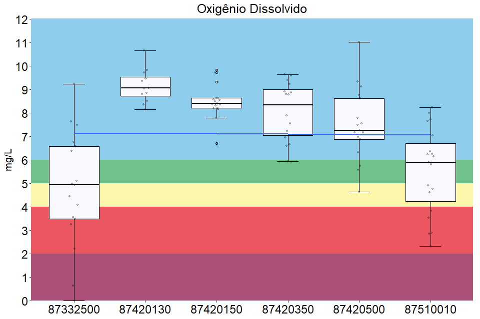

Oxigênio Dissolvido

```r
(graf_od <- plan_litoral_medio %>%
    ggplot(
      aes(
        x = cod_estacao,
        y = oxigenio_dissolvido,
        )
    )+
    annotate("rect",
             xmin = -Inf, xmax = Inf,
             ymin = -Inf, ymax = 2,
             alpha = 1,
             fill = "#ac5079")+ #>pior classe
    annotate("rect",
             xmin = -Inf, xmax = Inf,
             ymin = 2, ymax = 4,
             alpha = 1,
             fill = "#eb5661")+ #classe 4
    annotate("rect",
             xmin = -Inf, xmax = Inf,
             ymin = 4, ymax = 5,
             alpha = 1,
             fill = "#fcf7ab")+ #classe 3
    annotate("rect",
             xmin = -Inf, xmax = Inf,
             ymin = 5, ymax = 6,
             alpha = 1,
             fill = "#70c18c")+ #classe 2
    annotate("rect",
             xmin = -Inf, xmax = Inf,
             ymin= 6, ymax = Inf,
             alpha = 1,
             fill = "#8dcdeb")+ #classe 1
    stat_boxplot(
      geom = 'errorbar',
      width = 0.3,
      position = position_dodge(width = 0.65),
      fun.data = f,
    )+
    stat_boxplot(
      width = 0.7,
      fill = '#F8F8FF',
      color = "black",
      fun.data = f,
      geom = "boxplot",
      outlier.shape = 1, #se deixar NA fica só o jitter, se não, deixa 1
    )+
    # facet_wrap(~periodo)+
    labs(
      title = "Oxigênio Dissolvido",
      x= NULL,
      y="mg/L"
    )+
   ggbeeswarm::geom_quasirandom(
     grouponX = TRUE,
     size = 1.2,
     alpha = .25,
     width = .07,
   )+
   scale_y_continuous(
      expand = expansion(mult = c(0,0)),
      n.breaks = 11,
      # limits = c(-0.3,21)
      limits = c(
        min(plan_litoral_medio$oxigenio_dissolvido, na.rm = TRUE),
        max(plan_litoral_medio$oxigenio_dissolvido, na.rm = TRUE)+1)
    )+
   # scale_x_discrete(limits = c("87398500",
    #                             "87398980",
    #                             "87398900",
    #                             "87398950",
    #                             "87405500",
    #                             "87406900",
    #                             "87409900"),
    #                  labels = c("PM1", "PM2", "PM3", "PM4", "PM5", "PM6", "PM7")
    # )+
    geom_smooth(
      method = "lm",
      se = FALSE, #se deixar TRUE gera o intervalo de confiança de 95%
      aes(group = 1),
      alpha = 0.5,
      na.rm = TRUE,
      size = 1
    )+
  theme_grafs()
)
```

### 7.1.2 DBO

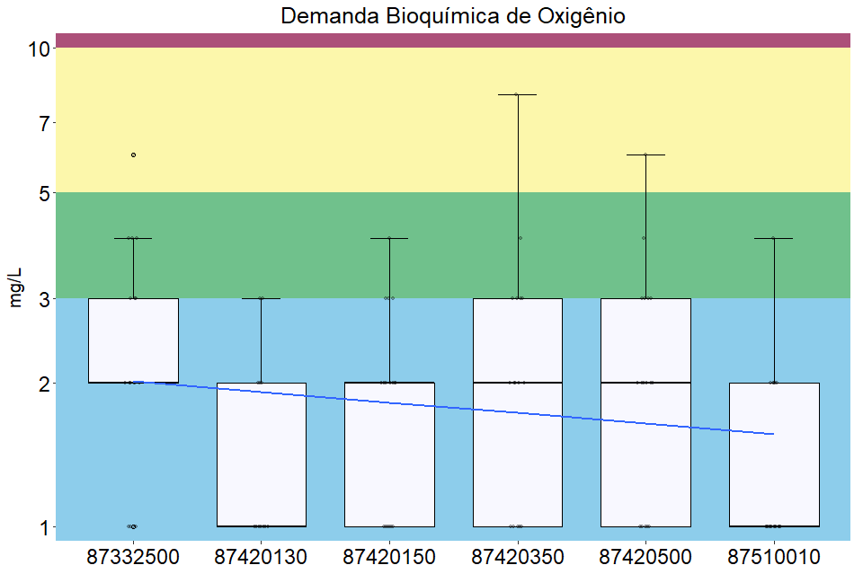

Demanda Bioquímica de Oxigênio

```r
(graf_dbo <- ggplot(plan_litoral_medio,
               aes(x = cod_estacao,
                   y = dbo))+
   annotate("rect",
            xmin = -Inf, xmax = Inf,
            ymin = 10, ymax = Inf,
            alpha = 1,
            fill = "#ac5079")+ #>pior classe
   annotate("rect",
            xmin = -Inf, xmax = Inf,
            ymin = 5, ymax = 10,
            alpha = 1,
            fill = "#fcf7ab")+ #classe 3
   annotate("rect",
            xmin = -Inf, xmax = Inf,
            ymin = 3, ymax = 5,
            alpha = 1,
            fill = "#70c18c")+ #classe 2
   annotate("rect",
            xmin = -Inf, xmax = Inf,
            ymin = 0, ymax = 3,
            alpha = 1,
            fill = "#8dcdeb")+ #classe 1
   stat_boxplot(
      geom = 'errorbar',
      width = 0.3,
      position = position_dodge(width = 0.65),
      fun.data = f,
    )+
    stat_boxplot(
      width = 0.7,
      fill = '#F8F8FF',
      color = "black",
      fun.data = f,
      geom = "boxplot",
      outlier.shape = 1, #se deixar NA fica só o jitter, se não, deixa 1
    )+
   # facet_wrap(~periodo)+
   labs(title = "Demanda Bioquímica de Oxigênio",
        x="Estação",
        y="mg/L")+
   ggbeeswarm::geom_quasirandom(
     # grouponX = FALSE,
     size = 1.2,
     alpha = .25,
     width = .07,
   )+
   # scale_x_discrete(limits = c("87398500",
   #                             "87398980",
   #                             "87398900",
   #                             "87398950",
   #                             "87405500",
   #                             "87406900",
   #                             "87409900"),
   #                  labels = c("PM1", "PM2", "PM3", "PM4", "PM5", "PM6", "PM7")
   # )+
   scale_y_continuous(expand = expansion(mult = c(0.03,0.03)),
                      n.breaks = 8,
                      limits = c(
                        min(plan_litoral_medio$dbo, na.rm = TRUE),
                        10
                        # max(plan_litoral_medio$dbo, na.rm = TRUE)
                        ),
                      trans = "log10")+
   geom_smooth(method = "lm",
               se=FALSE, #se deixar TRUE gera o intervalo de confiança de 95%
               aes(group=1),
               alpha=.5,
               na.rm = TRUE,
               size = 1)+
   theme_grafs()
)
```

### 7.1.3 *Escherichia coli*

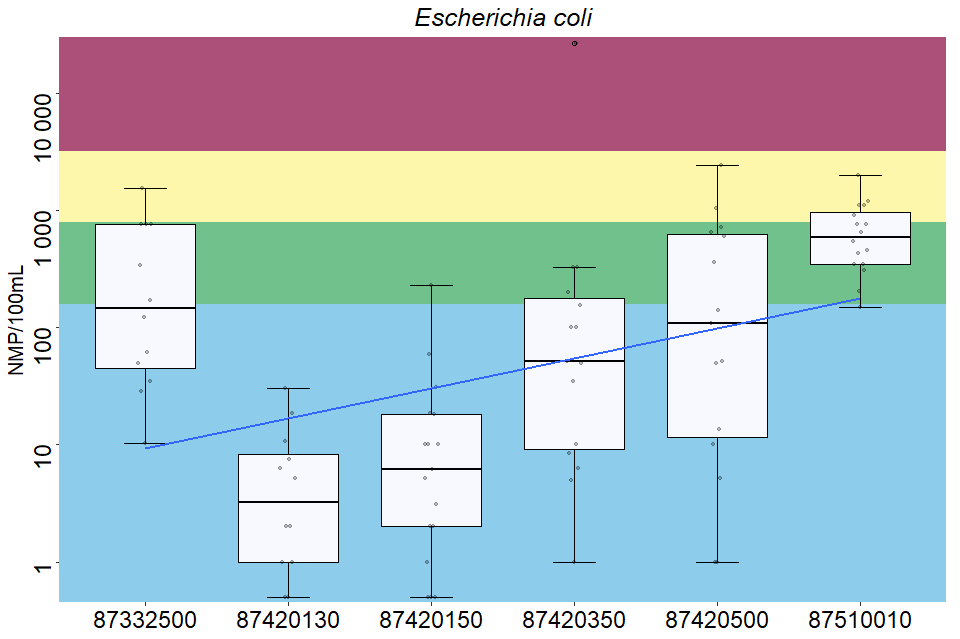

Escherichia-coli

```r
(graf_ecoli <- plan_litoral_medio %>%
   ggplot(aes(cod_estacao,
              e_coli))+
   annotate("rect",
            xmin = -Inf, xmax = Inf,
            ymin = 3200, ymax = Inf,
            alpha = 1,
            fill = "#ac5079")+ #>pior classe
   annotate("rect",
            xmin = -Inf, xmax = Inf,
            ymin = 800, ymax = 3200,
            alpha = 1,
            fill = "#fcf7ab")+ #classe 3
   annotate("rect",
            xmin = -Inf, xmax = Inf,
            ymin = 160, ymax = 800,
            alpha = 1,
            fill = "#70c18c")+ #classe 2
   annotate("rect",
            xmin = -Inf, xmax = Inf,
            ymin = 0, ymax = 160,
            alpha = 1,
            fill = "#8dcdeb")+ #classe 1
   stat_boxplot(geom = 'errorbar',
                width=0.3,
                position = position_dodge(width = 0.65))+
   geom_boxplot(fill='#F8F8FF',
                color="black",
                outlier.shape = 1, #se deixar NA fica só o jitter, se não, deixa 1
                width= 0.7)+
   # facet_wrap(~periodo)+
   labs(title = "*Escherichia coli*",
        x="Estação",
        y="NMP/100mL")+
   scale_y_continuous(expand = expansion(mult = c(0.01, 0.01)),
                      # n.breaks = 9,
                      n.breaks = 6,
                      limits = c(min(plan_litoral_medio$e_coli, na.rm = TRUE),
                                 max(plan_litoral_medio$e_coli, na.rm = TRUE)),
                      trans = "log10",
                      labels = scales::number_format(accuracy = 1,
                                                     decimal.mark = ",",
                                                     big.mark = " "))+
   ggbeeswarm::geom_quasirandom(
     size = 1.2,
     alpha = .25,
     width = .07,
   )+
 # scale_x_discrete(limits = c("87398500",
 #                             "87398980",
 #                             "87398900",
 #                             "87398950",
 #                             "87405500",
 #                             "87406900",
 #                             "87409900"),
 #                  labels = c("PM1", "PM2", "PM3", "PM4", "PM5", "PM6", "PM7")
 # )+
 geom_smooth(method = "lm",
 se=FALSE, #stardand error = desvio padrão -> se deixar TRUE gera o intervalo de confiança de 95%
             aes(group=1),
             alpha= 0.5, #transparencia de 50%
             na.rm = TRUE, #remover NAs
             size = 1)+
 theme_grafs()+
   theme(
     axis.text.y = element_text(
       angle = 90,
       # size=15,
       # face=2
     ),
     plot.title =
       element_markdown(
         hjust = 0.5,
         color = "black",
         size = 19),
   )
)
```

### 7.1.4 Fósforo Total

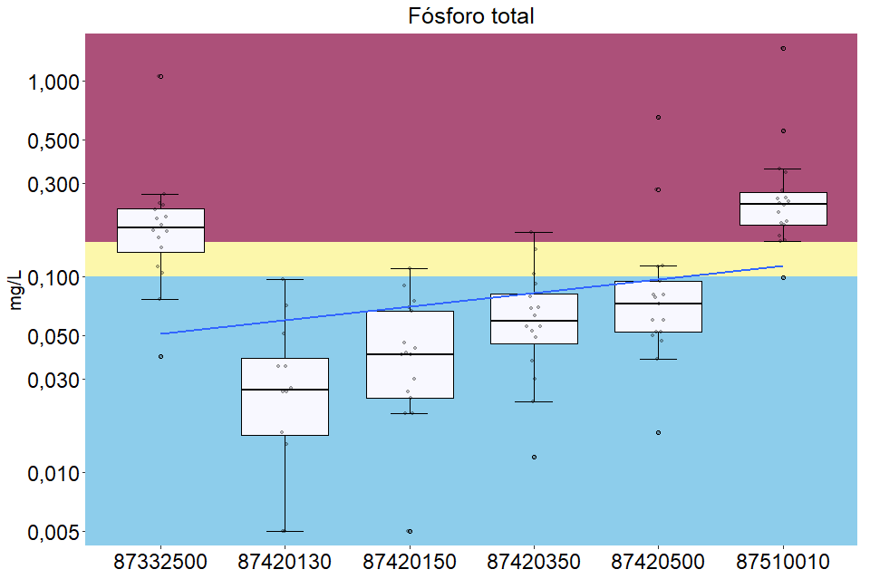

Fósforo total

```r
(graf_ptot <- ggplot(plan_litoral_medio,
                     aes(cod_estacao,
                         fosforo_total))+
   annotate("rect",
            xmin = -Inf, xmax = Inf,
            ymin = 0.15, ymax = Inf,
            alpha = 1,
            fill = "#ac5079")+ #>pior classe
   annotate("rect",
            xmin = -Inf, xmax = Inf,
            ymin = 0.1, ymax = 0.15,
            alpha = 1,
            fill = "#fcf7ab")+ #classe 3
   annotate("rect",
            xmin = -Inf, xmax = Inf,
            ymin = 0, ymax = 0.1,
            alpha = 1,
            fill = "#8dcdeb")+ #classe 1
   stat_boxplot(geom = 'errorbar',
                width=0.3,
                position = position_dodge(width = 0.65))+
   geom_boxplot(fill='#F8F8FF',
                color="black",
                outlier.shape = 1, #se deixar NA fica só o jitter, se não, deixa 1
                width= 0.7)+
   # facet_wrap(~periodo)+
   labs(title = "Fósforo total",
        x="Estação",
        y="mg/L")+
   scale_y_continuous(expand = expansion(mult = c(0.03,0.03)),
                      n.breaks = 8,
                      limits = c(min(plan_litoral_medio$fosforo_total, na.rm = TRUE),
                                 max(plan_litoral_medio$fosforo_total), na.rm = TRUE),
                      trans = "log10",
                      labels = scales::number_format(accuracy = .001,
                                                     decimal.mark = ",",
                                                     big.mark = " ")
   )+
   ggbeeswarm::geom_quasirandom(
     size = 1.2,
     alpha = .25,
     width = .07,
   )+
   # scale_x_discrete(limits = c("87398500",
   #                             "87398980",
   #                             "87398900",
   #                             "87398950",
   #                             "87405500",
   #                             "87406900",
   #                             "87409900"),
   #                  labels = c("PM1", "PM2", "PM3", "PM4", "PM5", "PM6", "PM7")
   # )+
   geom_smooth(method = "lm",
               se=FALSE, #se deixar TRUE gera o intervalo de confiança de 95%
               aes(group=1),
               alpha=.5,
               na.rm = TRUE,
               size = 1)+
   theme_grafs()
)
```

### 7.1.5 Nitrogênio amoniacal

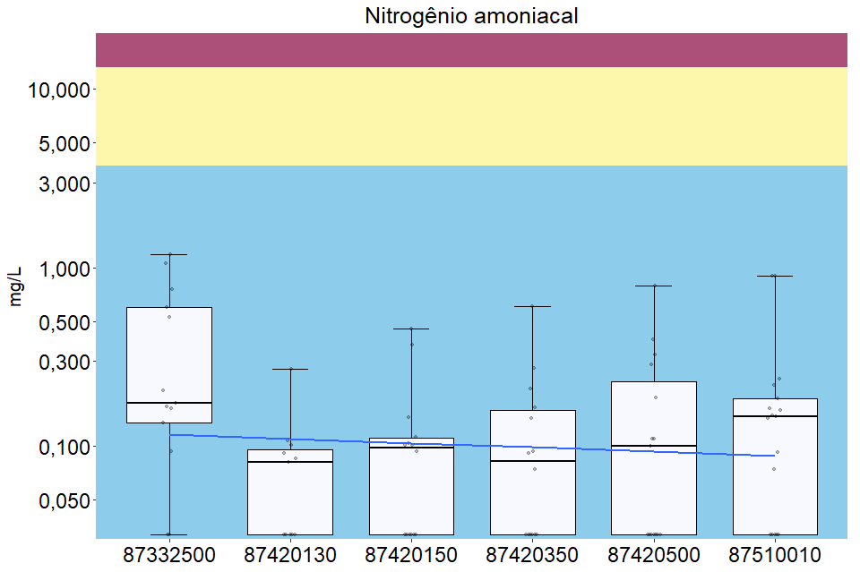

Nitrogênio Amoniacal

```r
(graf_namon <- ggplot(plan_litoral_medio,
                 aes(cod_estacao,
                     nitrogenio_amoniacal))+
   annotate("rect",
            xmin = -Inf, xmax = Inf,
            ymin = 13.3, ymax = Inf,
            alpha = 1,
            fill = "#ac5079")+ #>pior classe
   annotate("rect",
            xmin = -Inf, xmax = Inf,
            ymin = 3.7, ymax = 13.3,
            alpha = 1,
            fill = "#fcf7ab")+ #classe 3
   annotate("rect",
            xmin = -Inf, xmax = Inf,
            ymin = 0, ymax = 3.7,
            alpha = 1,
            fill = "#8dcdeb")+ #classe 1
   stat_boxplot(geom = 'errorbar',
                width=0.3,
                position = position_dodge(width = 0.65))+
   geom_boxplot(fill='#F8F8FF',
                color="black",
                outlier.shape = 1, #se deixar NA fica só o jitter, se não, deixa 1
                width= 0.7)+
   # facet_wrap(~periodo)+
   labs(title = "Nitrogênio amoniacal",
        x="Estação",
        y="mg/L")+
   scale_y_continuous(expand = expansion(mult = c(0.01, 0.05)),
                      n.breaks = 9,
                      limits = c(min(plan_litoral_medio$nitrogenio_amoniacal, na.rm = TRUE),
                                 15
                                 # max(plan_litoral_medio$nitrogenio_amoniacal, na.rm = TRUE)
                                 ),
                      trans = "log10",
                      labels = scales::number_format(accuracy = .001,
                                                     decimal.mark = ",",
                                                     big.mark = " "))+
   ggbeeswarm::geom_quasirandom(
     size = 1.2,
     alpha = .25,
     width = .07,
   )+
   # scale_x_discrete(limits = c("87398500",
   #                             "87398980",
   #                             "87398900",
   #                             "87398950",
   #                             "87405500",
   #                             "87406900",
   #                             "87409900"),
   #                  labels = c("PM1", "PM2", "PM3", "PM4", "PM5", "PM6", "PM7")
   # )+
   geom_smooth(method = "lm",
               se=FALSE, #se deixar TRUE gera o intervalo de confiança de 95%
               aes(group=1),
               alpha=.5,
               na.rm = TRUE,
               size = 1)+
   theme_grafs()
)
```

### 7.1.6 Turbidez

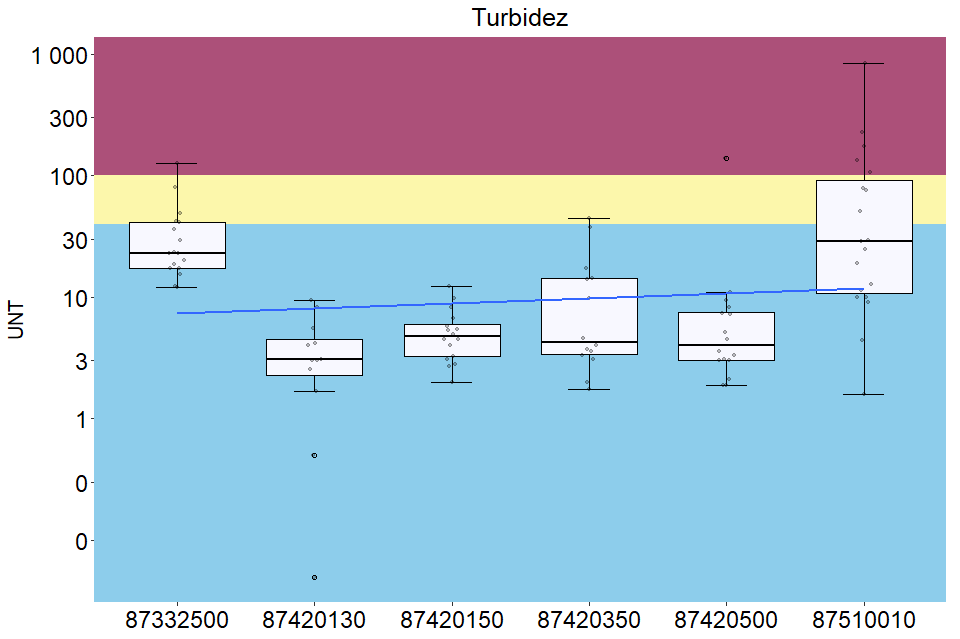

turbidez

```r
(graf_turb <- ggplot(plan_litoral_medio,
                   aes(cod_estacao,
                       turbidez))+
   annotate("rect",
            xmin = -Inf, xmax = Inf,
            ymin = 100, ymax = Inf,
            alpha = 1,
            fill = "#ac5079")+ #>pior classe
   annotate("rect",
            xmin = -Inf, xmax = Inf,
            ymin = 40, ymax = 100,
            alpha = 1,
            fill = "#fcf7ab")+ #classe 3
   annotate("rect",
            xmin = -Inf, xmax = Inf,
            ymin = 0, ymax = 40,
            alpha = 1,
            fill = "#8dcdeb")+ #classe 1
   stat_boxplot(geom = 'errorbar',
                width=0.3,
                position = position_dodge(width = 0.65))+
   geom_boxplot(fill='#F8F8FF',
                color="black",
                outlier.shape = 1, #se deixar NA fica só o jitter, se não, deixa 1
                width= 0.7)+
   # facet_wrap(~periodo)+
   labs(title = "Turbidez",
        x="Estação",
        y="UNT")+
   scale_y_continuous(expand = expansion(mult = c(0.05, 0.05)),
                      n.breaks = 8,
                      limits = c(
                        # 1,
                        min(plan_litoral_medio$turbidez, na.rm = TRUE),
                        # 500
                        max(plan_litoral_medio$turbidez, na.rm = TRUE)
                      ),
                      trans = "log10",
                      labels = scales::number_format(accuracy = 1,
                                                     decimal.mark = ",",
                                                     big.mark = " "))+
    ggbeeswarm::geom_quasirandom(
     size = 1.2,
     alpha = .25,
     width = .07,
   )+
   # scale_x_discrete(limits = c("87398500",
   #                             "87398980",
   #                             "87398900",
   #                             "87398950",
   #                             "87405500",
   #                             "87406900",
   #                             "87409900"),
   #                  labels = c("PM1", "PM2", "PM3", "PM4", "PM5", "PM6", "PM7")
   # )+
   geom_smooth(method = "lm",
               se=FALSE, #se deixar TRUE gera o intervalo de confiança de 95%
               aes(group=1),
               alpha=.5,
               na.rm = TRUE,
               size = 1)+
   theme_grafs()
)
```

### 7.1.7 pH

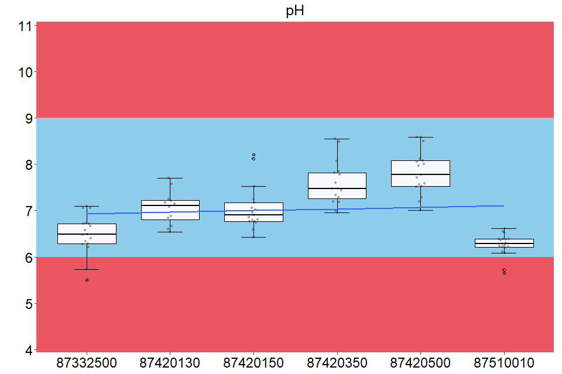

pH

```r
(graf_pH <- ggplot(plan_litoral_medio,
                 aes(cod_estacao,
                     ph))+
   annotate("rect",
            xmin=-Inf,
            xmax=Inf,
            ymin=-Inf,
            ymax=6,
            alpha=1,
            fill="#eb5661")+ #classe 4
   annotate("rect",
            xmin=-Inf,
            xmax=Inf,
            ymin=9,
            ymax=Inf,
            alpha=1,
            fill="#eb5661")+ #classe 4
   annotate("rect",
            xmin=-Inf,
            xmax=Inf,
            ymin=6,
            ymax=9,
            alpha=1,
            fill="#8dcdeb")+ #classe 1
   stat_boxplot(geom = 'errorbar',
                width=0.3,
                position = position_dodge(width = 0.65))+
   geom_boxplot(fill='#F8F8FF',
                color="black",
                outlier.shape = 1, #se deixar NA fica só o jitter, se não, deixa 1
                width= 0.7)+
   # facet_wrap(~periodo)+
   labs(title = "pH",
        x="Estação",
        y="")+
   scale_y_continuous(expand = expansion(mult = c(0.01, 0.01)),
                      n.breaks = 8,
                      limits = c(4,11),
                      labels = scales::number_format(accuracy = 1,
                                                     decimal.mark = ",",
                                                     big.mark = " ")
                      )+
    ggbeeswarm::geom_quasirandom(
     size = 1.2,
     alpha = .25,
     width = .07,
   )+
   # scale_x_discrete(limits = c("87398500",
   #                             "87398980",
   #                             "87398900",
   #                             "87398950",
   #                             "87405500",
   #                             "87406900",
   #                             "87409900"),
   #                  labels = c("PM1", "PM2", "PM3", "PM4", "PM5", "PM6", "PM7")
   # )+
   geom_smooth(method = "lm",
               se=FALSE, #se deixar TRUE gera o intervalo de confiança de 95%
               aes(group=1),
               alpha=.5,
               na.rm = TRUE,
               size = 1)+
   theme_grafs()
)
```

### 7.1.8 Sólidos Totais

[figure not shown]

sólidos-totais

```r
(graf_solidos_totais <- ggplot(plan_litoral_medio,
                               aes(cod_estacao,
                                   solidos_totais))+
   annotate("rect",
            xmin = -Inf, xmax = Inf,
            ymin = 500, ymax = Inf,
            alpha = 1,
            fill="#ac5079")+ #>pior classe
   annotate("rect",
            xmin = -Inf, xmax = Inf,
            ymin = -Inf, ymax = 500,
            alpha = 1,
            fill="#8dcdeb")+ #classe 1
   stat_boxplot(geom = 'errorbar',
                width=0.3,
                position = position_dodge(width = 0.65))+
   geom_boxplot(fill='#F8F8FF',
                color="black",
                outlier.shape = 1, #se deixar NA fica só o jitter, se não, deixa 1
                width= 0.7)+
   # facet_wrap(~periodo)+
   labs(title = "Sólidos totais",
        x="Estação",
        y="")+
   scale_y_continuous(expand = expansion(mult = c(0.01, 0.05)),
                      n.breaks = 8,
                      limits = c(0,
                                 max(plan_litoral_medio$solidos_totais, na.rm = TRUE)),
                      labels = scales::number_format(accuracy = 1,
                                                     decimal.mark = ",",
                                                     big.mark = " "))+
   ggbeeswarm::geom_quasirandom(
     size = 1.2,
     alpha = .25,
     width = .07,
   )+
   # scale_x_discrete(limits = c("87398500",
   #                             "87398980",
   #                             "87398900",
   #                             "87398950",
   #                             "87405500",
   #                             "87406900",
   #                             "87409900"),
   #                  labels = c("PM1", "PM2", "PM3", "PM4", "PM5", "PM6", "PM7")
   # )+
   geom_smooth(method = "lm",
               se=FALSE, #se deixar TRUE gera o intervalo de confiança de 95%
               aes(group=1),
               alpha=.5,
               na.rm = TRUE,
               size = 1)+
   theme_grafs()
)
```

### 7.1.9 Condutividade

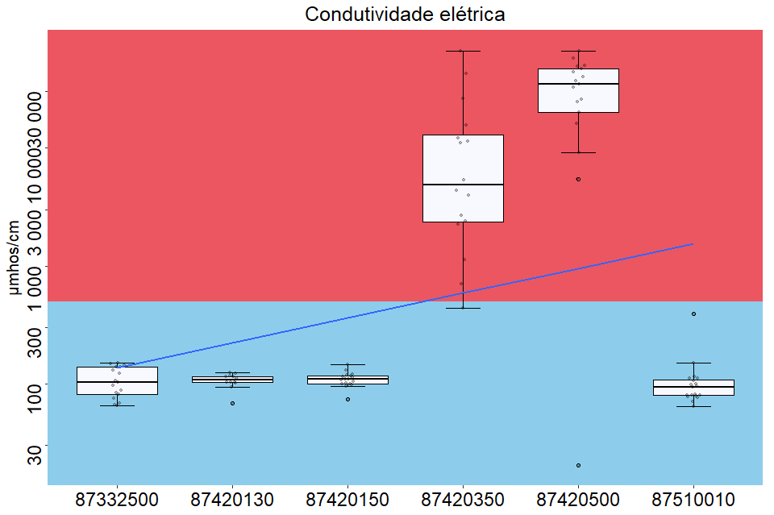

condutividade-eletrica

```r
(graf_cond_elet <- ggplot(plan_litoral_medio,
                          aes(cod_estacao,
                              condutividade))+
   annotate("rect",
            xmin = -Inf, xmax = Inf,
            ymin = 500, ymax = Inf,
            alpha = 1,
            fill = "#eb5661")+ #classe 4
   annotate("rect",
            xmin = -Inf, xmax = Inf,
            ymin = 0, ymax = 500,
            alpha = 1,
            fill = "#8dcdeb")+ #classe 1
   stat_boxplot(geom = 'errorbar',
                width=0.3,
                position = position_dodge(width = 0.65))+
   geom_boxplot(fill='#F8F8FF',
                color="black",
                outlier.shape = 1, #se deixar NA fica só o jitter, se não, deixa 1
                width= 0.7)+
   # facet_wrap(~periodo)+
   labs(title = "Condutividade elétrica",
        x="Estação",
        y="µmhos/cm")+
   scale_y_continuous(expand = expansion(mult = c(0.05, 0.05)),
                      n.breaks = 8,
                      limits = c(min(plan_litoral_medio$condutividade, na.rm = TRUE),
                                 max(plan_litoral_medio$condutividade, na.rm = TRUE)),
                      trans = "log10",
                      labels = scales::number_format(accuracy = 1,
                                                     decimal.mark = ",",
                                                     big.mark = " "))+
   ggbeeswarm::geom_quasirandom(
     size = 1.2,
     alpha = .25,
     width = .07,
   )+
   # scale_x_discrete(limits = c("87398500",
   #                             "87398980",
   #                             "87398900",
   #                             "87398950",
   #                             "87405500",
   #                             "87406900",
   #                             "87409900"),
   #                  labels = c("PM1", "PM2", "PM3", "PM4", "PM5", "PM6", "PM7")
   # )+
   geom_smooth(method = "lm",
               se=FALSE, #se deixar TRUE gera o intervalo de confiança de 95%
               aes(group=1),
               alpha=.5,
               na.rm = TRUE,
               size = 1)+
   theme_grafs()+
   theme(
     axis.text.y = element_text(
       angle = 90,
       # size=15,
       # face=2
     )
   )
)
```

## 7.2 Análise ao longo do tempo

Para gerar um gráfico ao longo do tempo pra cada uma das estações é necessário alterar o `ano_inicial` e o `ano_final`. Também é necessário selecionar qual parâmetro que se quer fazer a visualização.

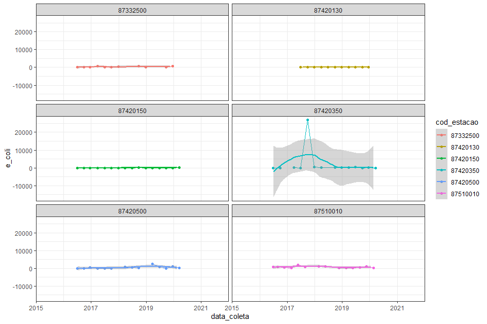

```r
ano_inicial <- 2015
ano_final <- 2022

(timeline <- plan_litoral_medio %>%
  filter(ano_coleta > ano_inicial &
           ano_coleta <= ano_final) %>%
  dplyr::select(cod_estacao, e_coli, data_coleta) %>%
  group_by(cod_estacao) %>%
  ggplot(
    aes(x = data_coleta,
        y = e_coli,
        color = cod_estacao
    ))+
    geom_line(
      # aes(color = CODIGO),
      na.rm = TRUE)+
    geom_point(
      # aes(color = CODIGO),
      na.rm = TRUE)+
    scale_x_date(
      limits = as.Date(c(
        ymd(glue("{ano_inicial}-01-01")),
        ymd(glue("{ano_final}-01-01"))
        # NA #pode usar NA também
      )),
      expand = c(0.0, 0.0),
      date_breaks = "2 years",
      minor_breaks = "1 years",
      date_labels = "%Y",
    )+
  # geom_smooth(
  #   method = "lm", #regressao linear
  #   se = TRUE, #se deixar TRUE gera o intervalo de confiança de 95%
  #   aes(group = 1),
  #   alpha =.5,
  #   na.rm = TRUE,
  #   size = 0.3,
  #   # fullrange = TRUE,
  #   show.legend = TRUE
  # )+
  stat_smooth(
    geom = "smooth",
    # span = 0.2,
    se = TRUE, #se deixar TRUE gera o intervalo de confiança de 95%
    # aes(group = 1),
    # alpha =.5,
    na.rm = TRUE,
    # size = 0.3,
    fullrange = TRUE,
    show.legend = TRUE
  )+
  facet_wrap(
    ~cod_estacao,
    nrow = 4,
  )+
  theme_bw()
)
```

## 7.3 Correlação

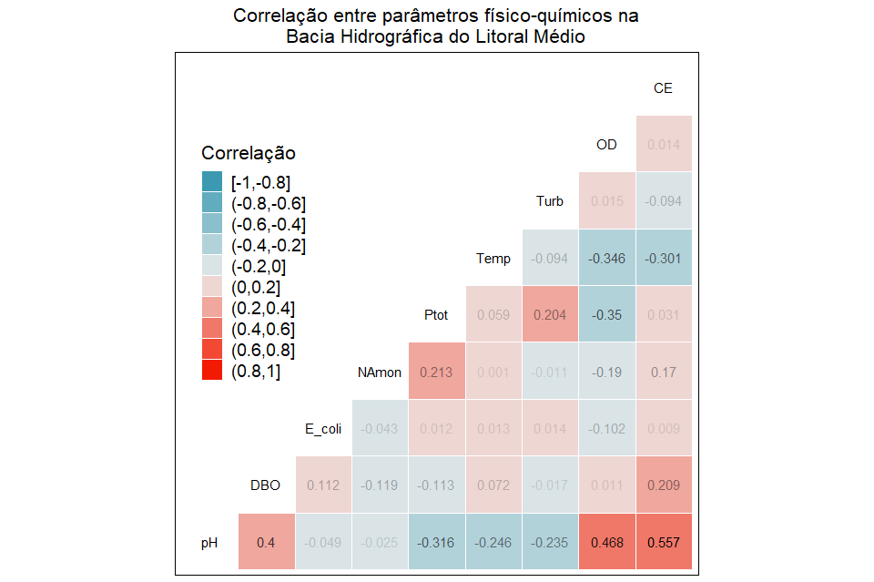

correlação-parametros-qualidade-agua

```r
parametros_iqa_lit_medio <- plan_litoral_medio %>%
  dplyr::select(cod_estacao,
         ph,
         dbo,
         e_coli,
         nitrogenio_amoniacal,
         # nitro_kjeldahl,
         # nitro_total,
         fosforo_total,
         temperatura_da_agua,
         turbidez,
         solidos_totais,
         oxigenio_dissolvido,
         condutividade,
         ano_coleta
         )

parametros_iqa_lit_medio %>%
  dplyr::select(
    -cod_estacao,
    -ano_coleta,
    -solidos_totais
    ) %>%
  # group_by(cod_estacao) %>%
  rename(
    CE = condutividade,
    OD = oxigenio_dissolvido,
    # ST = solidos_totais,
    Turb = turbidez,
    Temp = temperatura_da_agua,
    Ptot = fosforo_total,
    NAmon = nitrogenio_amoniacal,
    pH = ph,
    DBO = dbo,
    E_coli = e_coli
    # NTK = nitro_kjeldahl
  ) %>%
  ggcorr(
    method =
    "complete.obs",
    # "pearson",
    # "pairwise",
    name = "Correlação",
    label = TRUE,
    label_alpha = TRUE,
    digits = 3,
    low = "#3B9AB2",
    mid = "#EEEEEE",
    high = "#F21A00",
    # palette = "RdYlBu",
    layout.exp = 0,
    legend.position = "left",
    label_round = 3,
    # legend.size = 18,
    geom = "tile",
    nbreaks = 10,
  )+
  labs(title = "Correlação entre parâmetros físico-químicos na\nBacia Hidrográfica do Litoral Médio")+
  theme_linedraw()+
  theme(
    legend.position = c(0.15, 0.6),
    legend.title = element_text(size = 16),
    legend.text = element_text(size = 14),
    # legend.spacing = unit(element_text(),
                          # units = 5)
    plot.title = element_text(hjust = 0.5,
                              size = 16)
  )
```

### 7.3.1 Correlação entre parâmetros que compõem o IQA com significância estatística

```r
# Gráfico das correlações entre todos os parâmetros com significância
correl_IQA_lit_medio <- parametros_iqa_lit_medio %>%
  dplyr::select(-cod_estacao) %>%
  ggpairs(title = "Correlação entre parâmetros que compõem o IQA",
          axisLabels = "show")
# correl_IQA_lit_medio
```

## 7.4 Salvar os gráficos

Os gráficos ficarão salvos em uma pasta que irá ser criada a partir do código.

```r
ggsave("graf_od.png",
       plot = graf_od, #alteracao
       path = "./graficos",
       dpi = 300,
       type = "cairo")
```

# 8 Mapas

## 8.1 Pacotes pra geração de mapas

```r
pacman::p_load(raster, leaflet, sf
               # prettymapr, rjson, rosm,
               # ggspatial
               # rgdal, rgeos,
               # gtools, tidyverse, rnaturalearth,
               # rnaturalearthdata, reticulate, maptools,
               # maps, ggplot2, ggspatial, rgeos, ggmap
               )
```

## 8.2 Mapa estático

Importando as informações necessárias pra gerar mapas de precipitação.  
Fonte: GADM [^1], [^2]

```r
Brasil <- getData(
  'GADM',
  country = 'Brazil',
  level = 3
) %>%
  st_as_sf()

RS <- subset(Brasil,
             NAME_1 == "Rio Grande do Sul")

lbl <- data.frame(month_abb = month.abb,
                  mes = 1:12)

plan_litoral_medio %>%
  ggplot(
    # aes(x = longtitude,
    #     y = latitude,
    #     map_id = region)
  )+
  geom_sf(
    data = RS
  )+
  theme_bw()
```

**plot**

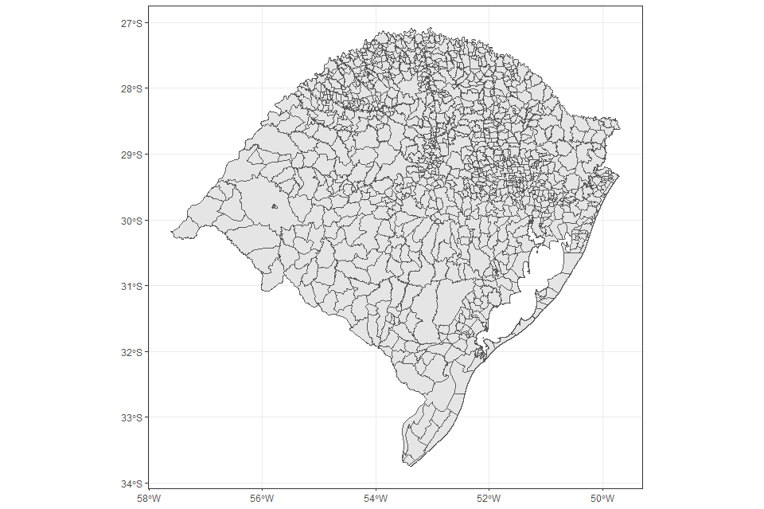

Mapa estático do RS

```r
# Definindo o SRC
RS <- RS %>%
  st_transform (crs = 4674) #4326 = WGS84, 4674 = SIRGAS2000
```

## 8.3 Mapa interativo com localização dos pontos de monitoramento

```r
leaflet(RS) %>%
  addProviderTiles(
    "Esri.WorldImagery" #Imagem de satélite
    # "OpenStreetMap.Mapnik" #OpenStreetMap -> Software livre
  ) %>%
  addCircleMarkers(
    data = plan_litoral_medio,
    lng = ~longitude,
    lat = ~latitude,
    popup = ~paste(
      "<b>Estação:</b>",{cod_estacao},"<br>",
      "<b>Recurso hídrico:</b>", recurso_hidrico, "<br>",
      "<b>Município:</b>", municipio,
      sep = " "
    )
  )
```

[interactive chart not shown]

Mapa interativo

## 8.4 Mapa de precipitação anual

```r
# st_centroid(RS)
#
# Prec <- getData(
#   "worldclim",
#   var = "prec",
#   res = 0.5,
#   lat = c(-30.033056, -29.68417), #procurar lat long no google e alterar aqui
#   lon = c(-51.230000, -53.80694)
# )
#
# Prec_RS <- Prec %>%
#   crop(RS) %>%
#   mask(RS, na.rm = TRUE)
#
# plot(Prec_RS)
#
# PPAnual_RS <- do.call("sum",
#                        unstack(Prec_RS))
# plot(PPAnual_RS)
```

```r
# vls <- rasterToPoints(Prec_RS) %>%
#   as_tibble() %>%
#   gather(var, value, -x, -y) %>%
#   mutate(mes = parse_number(var)) %>%
#   inner_join(., lbl, by = 'mes') %>%
#   dplyr::select(x, y, month_abb, value) %>%
#   mutate(month_abb = factor(month_abb, levels = month.abb))
#
# vls %>%
#   filter(month_abb == 'Jan')
#
# summary(vls$value) #descobre o valor mínimo, médio e máximo de precipitação
```

## 8.5 Mapa com precipitação mensal

Caso queira gerar um mapa com a precipitação mensal, alternar o include para `TRUE`. A geração desse mapa demanda bastante processamento, recomendável manter `include = FALSE` e `echo = FALSE`.

# 9 Links úteis

## 9.1 Cheatsheets

[Cheatsheets](https://posit.co/resources/cheatsheets/)

[GitHub com as versões mais atualizadas](https://github.com/rstudio/cheatsheets/)

[ggplot2 cheatsheet](https://posit.co/wp-content/uploads/2022/10/data-visualization-1.pdf)

[ggplot2 cheatsheet em português](https://raw.githubusercontent.com/rstudio/cheatsheets/main/translations/portuguese/data-visualization_pt.pdf)

[manipulação de dados em português](https://raw.githubusercontent.com/rstudio/cheatsheets/main/translations/portuguese/data-wrangling_pt.pdf)

[dplyr cheatsheet](https://posit.co/wp-content/uploads/2022/10/data-transformation-1.pdf)

## 9.2 Rmarkdown

[Tutorial sobre RMarkdown](https://youtu.be/18AUZOWAazg)

[Rmarkdown basics](https://rmarkdown.rstudio.com/authoring_basics.html)

[RMarkdown: The definitive guide](https://bookdown.org/yihui/rmarkdown/)

[knitr](https://yihui.org/knitr/options/)

## 9.3 Canais no Youtube

[Pat Schloss](https://www.youtube.com/@Riffomonas) #esse cara é genial

[Ambiental Pro Dev](https://www.youtube.com/@ambientalprodev5379)

# Ainda precisa ser implementado/ajustado

- RSÁgua deve buscar dados anteriores a 2015.
- A Fepam tem os dados de `altitude` das estações. A partir disso pode ser calculado o `% de saturação de Oxigênio Dissolvido`, necessário para o cálculo do IQA.
- Tornar a coluna de `chuva_24h` como factor.
- A coluna `hora_coleta` está com formato incorreto.
- Gerar um `Shiny Web App`
- Tornar a coluna de `municipio` com apenas a primeira letra maiúscula.
- Sincronização via GitHub
- Aprender a gerar o mapa de precipitação mensal pra todo o RS
  - O RS está entre 2 fusos, então acaba “partindo no meio” a figura
- Futuramente: integração via Google Sheets.

# Informações adicionais

E-mail para contato: leonardofwink@gmail.com

GitHub: https://github.com/leonardofwink/

LinkedIn: https://www.linkedin.com/in/leonardofwink/

[^1]: https://gadm.org/maps/BRA.html
[^2]: https://gadm.org/data.html